# PART A:Convolutional Neural Network

### Importing Libraries

```python
import tensorflow as tf
from keras.models import Sequential
from keras.layers import Dense, Conv2D, Flatten , MaxPooling2D, Dropout
from tensorflow.keras.optimizers import Adam ,SGD
from tensorflow.keras.callbacks import EarlyStopping
from tensorflow.keras.layers import BatchNormalization, ActivityRegularization
from tensorflow.keras import regularizers
import numpy as np
import pandas as pd
from matplotlib import pyplot as plt
from sklearn import model_selection
from sklearn import preprocessing
from PIL import Image

from tensorflow.keras.preprocessing.image  import ImageDataGenerator
from tensorflow.keras.preprocessing  import image
from tensorflow.keras.optimizers import RMSprop
from PIL import Image # pip install Pillow
import cv2 # pip install opencv-python
import os

os.chdir(r'C:\Users\limso\Downloads\DELE\DELE\CA2\Dataset for CA1 part A - AY2425S1')
```

```python
# Fix random seed for reproducibility
seed = 1
np.random.seed(seed)
tf.random.set_seed(seed)
tf.keras.utils.set_random_seed(0)
```

```python
import tensorflow as tf
gpus = tf.config.experimental.list_physical_devices('GPU')
for gpu in gpus:
  tf.config.experimental.set_memory_growth(gpu, True)
```

### Exploratory Data Analysis

## Class Distributions

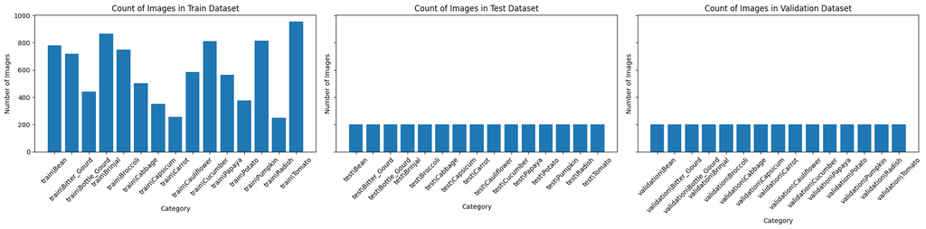

```python
import os
import matplotlib.pyplot as plt

def count_images_in_directory(directory):
    counts = {}
    for root, dirs, files in os.walk(directory):
        for file in files:
            if file.endswith(('.jpg', '.jpeg', '.png', '.bmp', '.gif')):
                category = root.split('/')[-1]
                counts[category] = counts.get(category, 0) + 1
    return counts

# Example usage:
dataset_directory = ["train","test","validation"]

# Plotting in subplots
fig, axs = plt.subplots(1, 3, figsize=(20, 5), sharey=True)

for i in range(3):
    axs[i].bar(count_images_in_directory(dataset_directory[i]).keys(), count_images_in_directory(dataset_directory[i]).values())
    axs[i].set_xlabel('Category')
    axs[i].set_ylabel('Number of Images')
    axs[i].tick_params(axis='x', rotation=45)

axs[0].set_title(f'Count of Images in Train Dataset')
axs[1].set_title(f'Count of Images in Test Dataset')
axs[2].set_title(f'Count of Images in Validation Dataset')

plt.tight_layout()
plt.show()
```

**Observation**

As we can see from the bar graphs, the dataset is imbalanced

## Visualising the Dataset

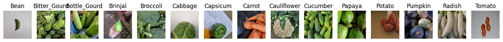

```python
from PIL import Image
import os
import matplotlib.pyplot as plt

def plot_first_image_of_each_dataset(directory):
    categories = os.listdir(directory)
    num_categories = len(categories)
    fig, axes = plt.subplots(1, num_categories, figsize=(15, 5))

    for i, category in enumerate(categories):
        category_dir = os.path.join(directory, category)
        if os.path.isdir(category_dir):
            for root, dirs, files in os.walk(category_dir):
                for file in files:
                    if file.endswith(('.jpg', '.jpeg', '.png', '.bmp', '.gif')):
                        image_path = os.path.join(root, file)
                        image = Image.open(image_path)
                        axes[i].imshow(image)
                        axes[i].axis('off')
                        axes[i].set_title(f'{category}')
                        break
                break

    plt.tight_layout()
    plt.show()

plot_first_image_of_each_dataset("train")
```

## Image Averaging

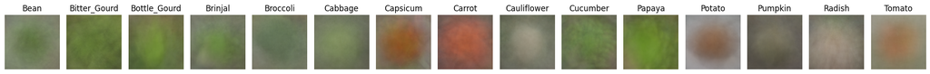

```python
def plot_image_averaging_of_each_dataset(directory):
    categories = os.listdir(directory)
    num_categories = len(categories)
    fig, axes = plt.subplots(1, num_categories, figsize=(20, 5))

    for i, category in enumerate(categories):
        category_dir = os.path.join(directory, category)
        if os.path.isdir(category_dir):
            image_files = [file for file in os.listdir(category_dir) if file.endswith(('.jpg', '.jpeg', '.png', '.bmp', '.gif'))]
            if len(image_files) > 0:
                avg_image = np.zeros((224, 224, 3), dtype=np.float32)
                for image_file in image_files:
                    image_path = os.path.join(category_dir, image_file)
                    image = np.array(Image.open(image_path).resize((224, 224)))
                    avg_image += image.astype(np.float32)
                avg_image /= len(image_files)

                axes[i].imshow(avg_image.astype(np.uint8))
                axes[i].axis('off')
                axes[i].set_title(f'{category}')

    plt.tight_layout()
    plt.show()

dataset_directory = "train"
plot_image_averaging_of_each_dataset(dataset_directory)
```

From the above , even though the average images is blurry, we can still make out what the images are. Images with a similar shade like the green vegetables might cause problems for the model for its classification, which might suggest that it is harder to predict these classes

### Data Preprocessing & Dataset Loading

We need to rescale the data .grayscale and One Hot Encode it

```python
train = ImageDataGenerator(rescale=1/255)
validation = ImageDataGenerator(rescale= 1/255)
test = ImageDataGenerator(rescale= 1/255)
```

```python
print('Train Dataset')
train_dataset = train.flow_from_directory(r'train',
                                          target_size=(37,37),
                                          color_mode = 'grayscale',
                                          class_mode = 'categorical',
                                          batch_size = 9028)

print('Test Dataset')

test_dataset = test.flow_from_directory(r'test',
                                        target_size=(37,37),
                                        color_mode = 'grayscale',
                                        class_mode = 'categorical',
                                        batch_size = 3000)

print('Validation Dataset')

validation_dataset = validation.flow_from_directory(r'validation',
                                                    target_size=(37,37),
                                                    color_mode = 'grayscale',
                                                    class_mode = 'categorical',
                                                    batch_size = 3000)
```

```
Train Dataset
Found 9028 images belonging to 15 classes.
Test Dataset
Found 3000 images belonging to 15 classes.
Validation Dataset
Found 3000 images belonging to 15 classes.
```

```python
train_dataset.class_indices
```

```
{'Bean': 0,
 'Bitter_Gourd': 1,
 'Bottle_Gourd': 2,
 'Brinjal': 3,
 'Broccoli': 4,
 'Cabbage': 5,
 'Capsicum': 6,
 'Carrot': 7,
 'Cauliflower': 8,
 'Cucumber': 9,
 'Papaya': 10,
 'Potato': 11,
 'Pumpkin': 12,
 'Radish': 13,
 'Tomato': 14}
```

```python
train_dataset.classes
```

```
array([ 0,  0,  0, ..., 14, 14, 14])
```

```python
X_train , y_train = next(train_dataset)
X_test , y_test = next(test_dataset)
X_val , y_val = next(validation_dataset)
```

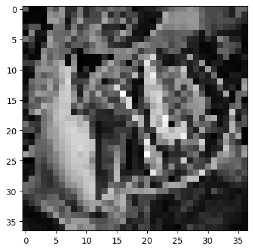

```python
plt.imshow(X_train[0],cmap='gray')
```

```python
X_train = X_train.reshape(X_train.shape[0], 37, 37, 1).astype('float32')
X_test = X_test.reshape(X_test.shape[0], 37, 37, 1).astype('float32')
X_val = X_val.reshape(X_val.shape[0], 37, 37, 1).astype('float32')
```

## Data Augmentation

We will use data augmentation to prevent overfitting of the model.

Augmentation introduces variability into the training samples, preventing the model from fitting noise in the data and improving its ability to generalize to new examples.

Note: We only augment the training dataset as we do not want to edit the validation and test data as they are used for evaluatation of the model's accuracy.

```python
def data_augmentation(x_train):
    imageArr = []
    for images in x_train:
        tf.convert_to_tensor(images)
        randomVal = np.random.randint(0,2)
        if randomVal == 1:
            image = tf.image.random_flip_left_right(images)
            image = tf.image.resize_with_crop_or_pad(
                image, (37,37,1)[0] + 4, (37,37,1)[1] + 4)
            image = tf.image.random_crop(
                image, size=(37,37,1)
            )
            images = image
        imageArr.append(images)
    return np.array(imageArr)
```

```python
X_train_aug = data_augmentation(np.copy(X_train))
```

### Baseline Model

#### Without Augmentation

```python
model_baseline = Sequential()
model_baseline.add(Conv2D(32, (3, 3), activation='relu', input_shape=(37, 37, 1)))
model_baseline.add(MaxPooling2D((2, 2)))
model_baseline.add(Conv2D(64, (3, 3), activation='relu'))
model_baseline.add(MaxPooling2D((2, 2)))
model_baseline.add(Flatten())
model_baseline.add(Dense(128, activation='relu'))
model_baseline.add(Dense(15, activation='softmax'))

model_baseline.compile(optimizer='adam', loss='categorical_crossentropy', metrics=['accuracy'])
```

```python
history = model_baseline.fit(X_train, y_train, epochs= 100, verbose=1, validation_data=(X_val, y_val))
```

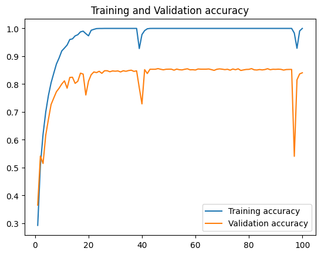

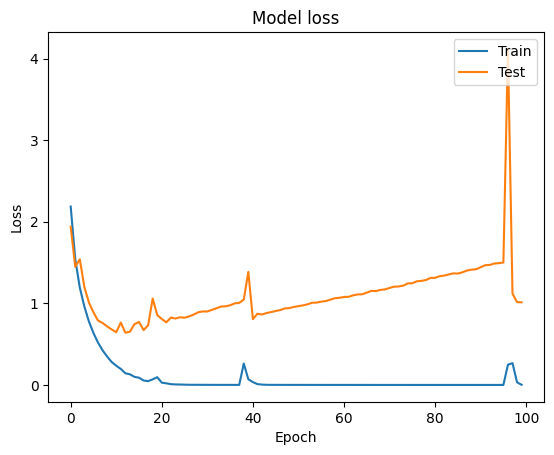

```python
accuracy = history.history['accuracy']
val_accuracy = history.history['val_accuracy']
loss = history.history['loss']
val_loss = history.history['val_loss']

epochs = range(1, len(accuracy) + 1)

plt.plot(epochs, accuracy, label='Training accuracy')
plt.plot(epochs, val_accuracy, label= 'Validation accuracy')
plt.title('Training and Validation accuracy')
plt.legend()
plt.figure()

def plot_loss(loss,val_loss):
  plt.figure()
  plt.plot(loss)
  plt.plot(val_loss)
  plt.title('Model loss')
  plt.ylabel('Loss')
  plt.xlabel('Epoch')
  plt.legend(['Train', 'Test'], loc='upper right')
  plt.show()

plot_loss(loss, val_loss)

plt.show()
```

```python
scores = model_baseline.evaluate(X_test, y_test)
print("\n%s: %.2f%%" % (model_baseline.metrics_names[1], scores[1]*100))
```

```
accuracy: 84.37%
```

We can see that the model is overfitting alot

#### With Augmentation

```python
model_baseline_aug = Sequential()
model_baseline_aug.add(Conv2D(32, (3, 3), activation='relu', input_shape=(37, 37, 1)))
model_baseline_aug.add(MaxPooling2D((2, 2)))
model_baseline_aug.add(Conv2D(64, (3, 3), activation='relu'))
model_baseline_aug.add(MaxPooling2D((2, 2)))
model_baseline_aug.add(Flatten())
model_baseline_aug.add(Dense(128, activation='relu'))
model_baseline_aug.add(Dense(15, activation='softmax'))

model_baseline_aug.compile(optimizer='adam', loss='categorical_crossentropy', metrics=['accuracy'])
```

```python
history = model_baseline_aug.fit(X_train_aug, y_train, epochs= 100, verbose=1, validation_data=(X_val, y_val))
```

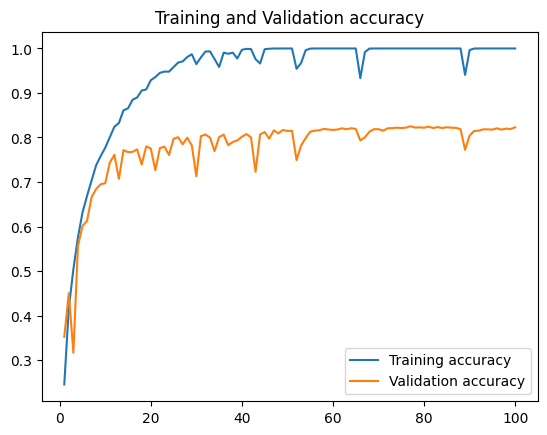

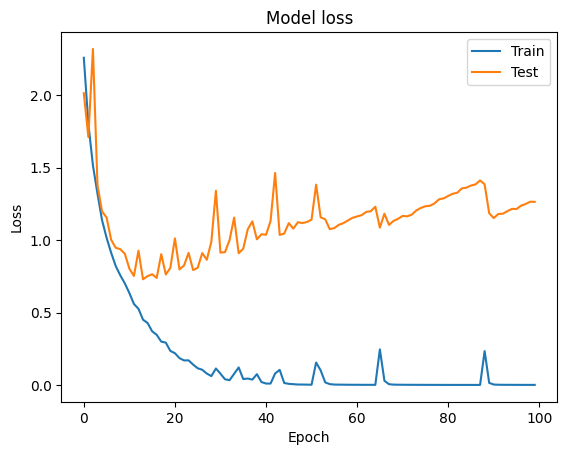

```python
accuracy = history.history['accuracy']
val_accuracy = history.history['val_accuracy']
loss = history.history['loss']
val_loss = history.history['val_loss']

epochs = range(1, len(accuracy) + 1)

plt.plot(epochs, accuracy, label='Training accuracy')
plt.plot(epochs, val_accuracy, label= 'Validation accuracy')
plt.title('Training and Validation accuracy')
plt.legend()
plt.figure()

def plot_loss(loss,val_loss):
  plt.figure()
  plt.plot(loss)
  plt.plot(val_loss)
  plt.title('Model loss')
  plt.ylabel('Loss')
  plt.xlabel('Epoch')
  plt.legend(['Train', 'Test'], loc='upper right')
  plt.show()

plot_loss(loss, val_loss)

plt.show()
```

```python
scores = model_baseline_aug.evaluate(X_test, y_test)
print("\n%s: %.2f%%" % (model_baseline_aug.metrics_names[1], scores[1]*100))
```

```
accuracy: 82.17%
```

### Model 37 Training

#### Without Augmentation

```python
model37 = Sequential()

# First Convolutional Block
model37.add(Conv2D(32, (3, 3), activation='relu', input_shape=(37, 37, 1)))
model37.add(BatchNormalization())
model37.add(Conv2D(32, (3, 3), activation='relu'))
model37.add(BatchNormalization())
model37.add(MaxPooling2D((2, 2)))
model37.add(Dropout(0.25))

# Second Convolutional Block
model37.add(Conv2D(64, (3, 3), activation='relu'))
model37.add(BatchNormalization())
model37.add(Conv2D(64, (3, 3), activation='relu'))
model37.add(BatchNormalization())
model37.add(MaxPooling2D((2, 2)))
model37.add(Dropout(0.3))

# Third Convolutional Block
model37.add(Conv2D(128, (3, 3), activation='relu'))
model37.add(BatchNormalization())
model37.add(Conv2D(128, (3, 3), activation='relu'))
model37.add(BatchNormalization())
model37.add(Dropout(0.4))

# Fully Connected Layers
model37.add(Flatten())
model37.add(Dense(128, activation='relu'))
model37.add(Dropout(0.4))

model37.add(Dense(64, activation='relu'))
model37.add(Dropout(0.3))

model37.add(Dense(15, activation='softmax'))
```

```python
# Define the learning rate
learning_rate = 0.0001

# Create Adam optimizer with specified learning rate
optimizer = Adam(learning_rate=learning_rate)

model37.compile(optimizer=optimizer, loss='categorical_crossentropy', metrics=['accuracy'])
```

```python
from sklearn.utils.class_weight import compute_class_weight
from sklearn.preprocessing import MultiLabelBinarizer

def generate_class_weights(class_series, multi_class=True, one_hot_encoded=True):
  if multi_class:
    if one_hot_encoded:
      class_series = np.argmax(class_series, axis=1)

    class_labels = np.unique(class_series)
    class_weights = compute_class_weight(class_weight='balanced', classes=class_labels, y=class_series)
    return dict(zip(class_labels, class_weights))
  else:
    mlb = None
    if not one_hot_encoded:
      mlb = MultiLabelBinarizer()
      class_series = mlb.fit_transform(class_series)

    n_samples = len(class_series)
    n_classes = len(class_series[0])

    class_count = [0] * n_classes
    for classes in class_series:
        for index in range(n_classes):
            if classes[index] != 0:
                class_count[index] += 1

    class_weights = [n_samples / (n_classes * freq) if freq > 0 else 1 for freq in class_count]
    class_labels = range(len(class_weights)) if mlb is None else mlb.classes_
    return dict(zip(class_labels, class_weights))

labels = y_train
class_weights = generate_class_weights(labels)
```

```python
history_37 = model37.fit(X_train, y_train, epochs= 150, verbose=1, validation_data=(X_val, y_val), class_weight=class_weights)
```

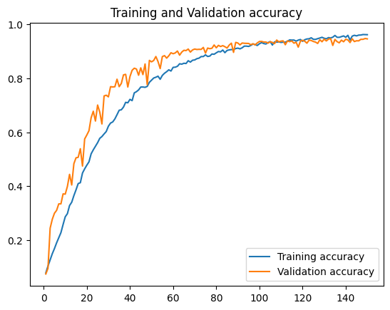

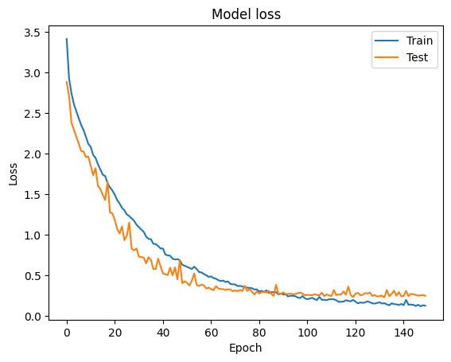

```python
accuracy = history_37.history['accuracy']
val_accuracy = history_37.history['val_accuracy']
loss = history_37.history['loss']
val_loss = history_37.history['val_loss']

epochs = range(1, len(accuracy) + 1)

plt.plot(epochs, accuracy, label='Training accuracy')
plt.plot(epochs, val_accuracy, label= 'Validation accuracy')
plt.title('Training and Validation accuracy')
plt.legend()
plt.figure()

def plot_loss(loss,val_loss):
  plt.figure()
  plt.plot(loss)
  plt.plot(val_loss)
  plt.title('Model loss')
  plt.ylabel('Loss')
  plt.xlabel('Epoch')
  plt.legend(['Train', 'Test'], loc='upper right')
  plt.show()

plot_loss(loss, val_loss)

plt.show()
```

```python
scores_37 = model37.evaluate(X_test, y_test)
print("\n%s: %.2f%%" % (model37.metrics_names[1], scores_37[1]*100))
```

```
accuracy: 94.97%
```

The model is well fitted and is consistent.It has a high accuracy as well.

#### With Augmentation

```python
model37_aug = Sequential()

# First Convolutional Block
model37_aug.add(Conv2D(32, (3, 3), activation='relu', input_shape=(37, 37, 1)))
model37_aug.add(BatchNormalization())
model37_aug.add(Conv2D(32, (3, 3), activation='relu'))
model37_aug.add(BatchNormalization())
model37_aug.add(MaxPooling2D((2, 2)))
model37_aug.add(Dropout(0.25))

# Second Convolutional Block
model37_aug.add(Conv2D(64, (3, 3), activation='relu'))
model37_aug.add(BatchNormalization())
model37_aug.add(Conv2D(64, (3, 3), activation='relu'))
model37_aug.add(BatchNormalization())
model37_aug.add(MaxPooling2D((2, 2)))
model37_aug.add(Dropout(0.3))

# Third Convolutional Block
model37_aug.add(Conv2D(128, (3, 3), activation='relu'))
model37_aug.add(BatchNormalization())
model37_aug.add(Conv2D(128, (3, 3), activation='relu'))
model37_aug.add(BatchNormalization())
model37_aug.add(Dropout(0.4))

# Fully Connected Layers
model37_aug.add(Flatten())
model37_aug.add(Dense(128, activation='relu'))
model37_aug.add(Dropout(0.4))  # Increased dropout for better regularization

model37_aug.add(Dense(64, activation='relu'))
model37_aug.add(Dropout(0.3))  # Adjusted dropout

model37_aug.add(Dense(15, activation='softmax'))
```

```python
model37_aug.compile(optimizer=optimizer, loss='categorical_crossentropy', metrics=['accuracy'])
```

```python
history = model37_aug.fit(X_train_aug, y_train, epochs= 150, verbose=1, validation_data=(X_val, y_val), class_weight=class_weights)
```

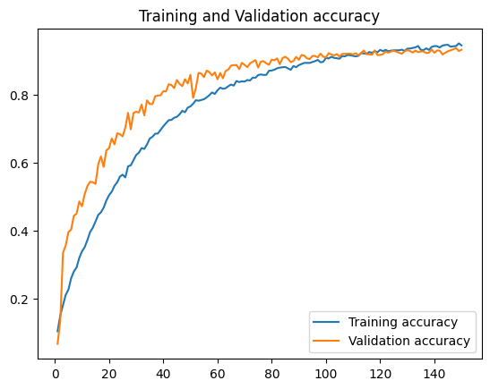

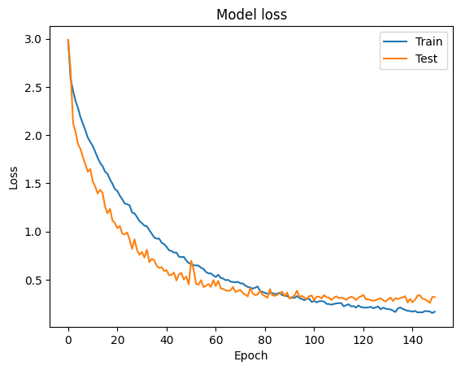

```python
accuracy = history.history['accuracy']
val_accuracy = history.history['val_accuracy']
loss = history.history['loss']
val_loss = history.history['val_loss']

epochs = range(1, len(accuracy) + 1)

plt.plot(epochs, accuracy, label='Training accuracy')
plt.plot(epochs, val_accuracy, label= 'Validation accuracy')
plt.title('Training and Validation accuracy')
plt.legend()
plt.figure()

def plot_loss(loss,val_loss):
  plt.figure()
  plt.plot(loss)
  plt.plot(val_loss)
  plt.title('Model loss')
  plt.ylabel('Loss')
  plt.xlabel('Epoch')
  plt.legend(['Train', 'Test'], loc='upper right')
  plt.show()

plot_loss(loss, val_loss)

plt.show()
```

```python
scores = model37_aug.evaluate(X_test, y_test)
print("\n%s: %.2f%%" % (model37_aug.metrics_names[1], scores[1]*100))
```

```
accuracy: 93.30%
```

### Final Model Evaluation(37 X 37)

Since the accuracy is the similar , we will evalaute the models by the loss, the model without data augmentation data has a lower loss.So we will be saving that model instead

```python
model37.summary()
```

```
Model: "sequential_2"
_________________________________________________________________
 Layer (type)                Output Shape              Param #
=================================================================
 conv2d_4 (Conv2D)           (None, 35, 35, 32)        320

 batch_normalization (BatchN  (None, 35, 35, 32)       128
 ormalization)

 conv2d_5 (Conv2D)           (None, 33, 33, 32)        9248

 batch_normalization_1 (Batc  (None, 33, 33, 32)       128
 hNormalization)

 max_pooling2d_4 (MaxPooling  (None, 16, 16, 32)       0
 2D)

 dropout (Dropout)           (None, 16, 16, 32)        0

 conv2d_6 (Conv2D)           (None, 14, 14, 64)        18496

 batch_normalization_2 (Batc  (None, 14, 14, 64)       256
 hNormalization)

 conv2d_7 (Conv2D)           (None, 12, 12, 64)        36928

 batch_normalization_3 (Batc  (None, 12, 12, 64)       256
 hNormalization)

 max_pooling2d_5 (MaxPooling  (None, 6, 6, 64)         0
 2D)

 dropout_1 (Dropout)         (None, 6, 6, 64)          0

 conv2d_8 (Conv2D)           (None, 4, 4, 128)         73856

 batch_normalization_4 (Batc  (None, 4, 4, 128)        512
 hNormalization)

 conv2d_9 (Conv2D)           (None, 2, 2, 128)         147584
```

[output cut: 8 more lines]

```
 dense_4 (Dense)             (None, 128)               65664

 dropout_3 (Dropout)         (None, 128)               0

 dense_5 (Dense)             (None, 64)                8256

 dropout_4 (Dropout)         (None, 64)                0

 dense_6 (Dense)             (None, 15)                975

=================================================================
Total params: 363,119
Trainable params: 362,223
Non-trainable params: 896
_________________________________________________________________
```

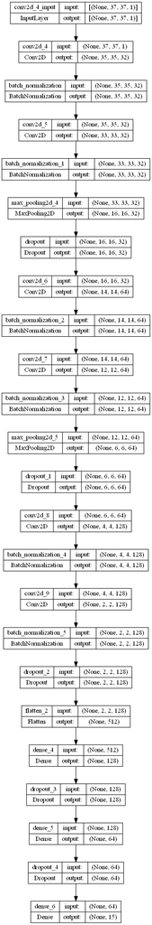

```python
from keras.utils.vis_utils import plot_model

# Plot the model
plot_model(model37, show_shapes=True, show_layer_names=True)
```

```python
model37.save_weights('model37_weights.h5')
model37.save('model37.h5')
```

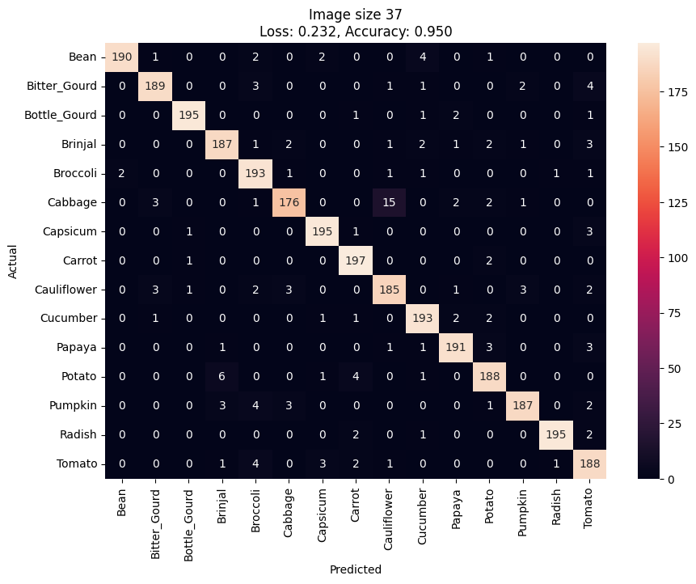

```python
y_pred = model37.predict(X_test)
from sklearn.metrics import confusion_matrix

confusion_matrix(np.argmax(y_test, axis=1), np.argmax(y_pred, axis=1))

#Graph the confusion matrix
import seaborn as sns
import pandas as pd

cm = confusion_matrix(np.argmax(y_test, axis=1), np.argmax(y_pred, axis=1))

pd.options.display.float_format = '{:.2f}'.format

df_cm = pd.DataFrame(cm, index = test_dataset.class_indices.keys(),
                    columns = test_dataset.class_indices.keys())

loss, accuracy = model37.evaluate(X_test, y_test)

plt.figure(figsize=(10,7))
sns.heatmap(df_cm, annot=True, fmt='d')
plt.title(f'Image size 37\nLoss: {loss:.3f}, Accuracy: {accuracy:.3f}')
plt.xlabel('Predicted')
plt.ylabel('Actual')
plt.show()
```

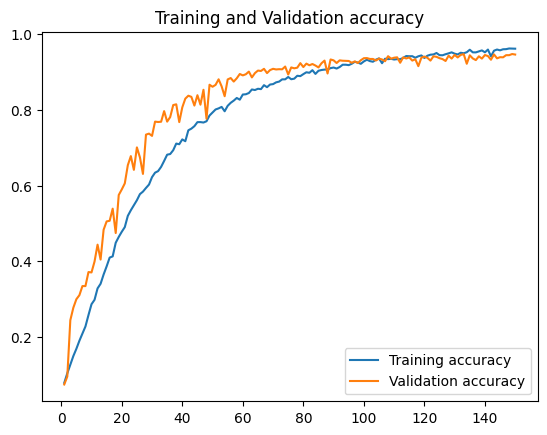

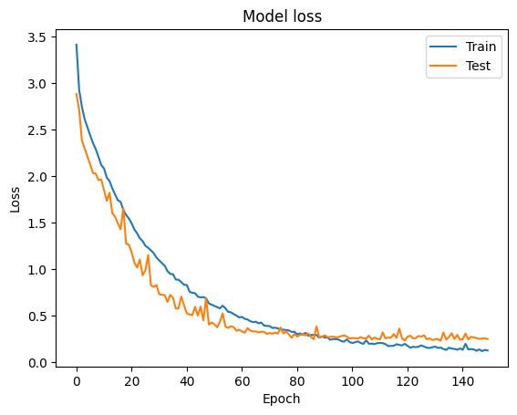

```python
accuracy = history_37.history['accuracy']
val_accuracy = history_37.history['val_accuracy']
loss = history_37.history['loss']
val_loss = history_37.history['val_loss']

epochs = range(1, len(accuracy) + 1)

plt.plot(epochs, accuracy, label='Training accuracy')
plt.plot(epochs, val_accuracy, label= 'Validation accuracy')
plt.title('Training and Validation accuracy')
plt.legend()
plt.figure()

def plot_loss(loss,val_loss):
  plt.figure()
  plt.plot(loss)
  plt.plot(val_loss)
  plt.title('Model loss')
  plt.ylabel('Loss')
  plt.xlabel('Epoch')
  plt.legend(['Train', 'Test'], loc='upper right')
  plt.show()

plot_loss(loss, val_loss)

plt.show()
```

```python
print("\n%s: %.2f%%" % (model37.metrics_names[1], scores_37[1]*100))
```

```
accuracy: 94.97%
```

### Model Improvement

for this section , i used my educated decision making to improve my models configuration of its architecture.

## Model 131 Training

```python
print('Train Dataset')
train_dataset = train.flow_from_directory(r'train',
                                          target_size=(131,131),
                                          color_mode = 'grayscale',
                                          class_mode = 'categorical',
                                          batch_size = 9028)

print('Test Dataset')

test_dataset = test.flow_from_directory(r'test',
                                        target_size=(131,131),
                                        color_mode = 'grayscale',
                                        class_mode = 'categorical',
                                        batch_size = 3000)

print('Validation Dataset')

validation_dataset = validation.flow_from_directory(r'validation',
                                                    target_size=(131,131),
                                                    color_mode = 'grayscale',
                                                    class_mode = 'categorical',
                                                    batch_size = 3000)
```

```
Train Dataset
Found 9028 images belonging to 15 classes.
Test Dataset
Found 3000 images belonging to 15 classes.
Validation Dataset
Found 3000 images belonging to 15 classes.
```

```python
X_train , y_train = next(train_dataset)
X_test , y_test = next(test_dataset)
X_val , y_val = next(validation_dataset)
```

```python
# Reshape every X so it can be fit into the model
X_train = X_train.reshape(X_train.shape[0], 131, 131, 1).astype('float32')
X_test = X_test.reshape(X_test.shape[0], 131,131, 1).astype('float32')
X_val = X_val.reshape(X_val.shape[0], 131, 131, 1).astype('float32')
```

```python
def data_augmentation(x_train):
    imageArr = []
    for images in x_train:
        tf.convert_to_tensor(images)
        randomVal = np.random.randint(0,2)
        if randomVal == 1:
            image = tf.image.random_flip_left_right(images)
            image = tf.image.resize_with_crop_or_pad(
                image, (131,131,1)[0] + 4, (131,131,1)[1] + 4)
            image = tf.image.random_crop(
                image, size=(131,131,1)
            )
            images = image
        imageArr.append(images)
    return np.array(imageArr)
```

```python
X_train_aug = data_augmentation(np.copy(X_train))
```

#### Without Augmentation

```python
model131 = Sequential()

# First Convolutional Block
model131.add(Conv2D(32, (3, 3), activation='relu', input_shape=(131, 131, 1)))
model131.add(BatchNormalization())
model131.add(Conv2D(32, (3, 3), activation='relu'))
model131.add(BatchNormalization())
model131.add(MaxPooling2D((2, 2)))
model131.add(Dropout(0.25))

# Second Convolutional Block
model131.add(Conv2D(64, (3, 3), activation='relu'))
model131.add(BatchNormalization())
model131.add(Conv2D(64, (3, 3), activation='relu'))
model131.add(BatchNormalization())
model131.add(MaxPooling2D((2, 2)))
model131.add(Dropout(0.3))

# Third Convolutional Block
model131.add(Conv2D(128, (3, 3), activation='relu'))
model131.add(BatchNormalization())
model131.add(Conv2D(128, (3, 3), activation='relu'))
model131.add(BatchNormalization())
model131.add(MaxPooling2D((2, 2)))
model131.add(Dropout(0.4))

# Fully Connected Layers
model131.add(Flatten())
model131.add(Dense(128, activation='relu'))
model131.add(Dropout(0.4))

model131.add(Dense(64, activation='relu'))
model131.add(Dropout(0.3))

model131.add(Dense(15, activation='softmax'))
```

```python
# Define the learning rate
learning_rate = 0.0001

# Create Adam optimizer with specified learning rate
optimizer = Adam(learning_rate=learning_rate)

model131.compile(optimizer=optimizer, loss='categorical_crossentropy', metrics=['accuracy'])
```

```python
from sklearn.utils.class_weight import compute_class_weight
from sklearn.preprocessing import MultiLabelBinarizer

def generate_class_weights(class_series, multi_class=True, one_hot_encoded=True):
  if multi_class:
    if one_hot_encoded:
      class_series = np.argmax(class_series, axis=1)

    class_labels = np.unique(class_series)
    class_weights = compute_class_weight(class_weight='balanced', classes=class_labels, y=class_series)
    return dict(zip(class_labels, class_weights))
  else:
    mlb = None
    if not one_hot_encoded:
      mlb = MultiLabelBinarizer()
      class_series = mlb.fit_transform(class_series)

    n_samples = len(class_series)
    n_classes = len(class_series[0])

    class_count = [0] * n_classes
    for classes in class_series:
        for index in range(n_classes):
            if classes[index] != 0:
                class_count[index] += 1

    class_weights = [n_samples / (n_classes * freq) if freq > 0 else 1 for freq in class_count]
    class_labels = range(len(class_weights)) if mlb is None else mlb.classes_
    return dict(zip(class_labels, class_weights))

labels = y_train
class_weights = generate_class_weights(labels)
```

```python
history_131 = model131.fit(X_train, y_train, epochs=150 , verbose=1, validation_data=(X_val, y_val), class_weight=class_weights)
```

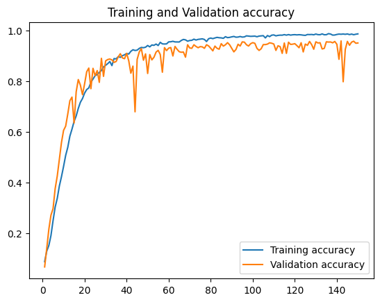

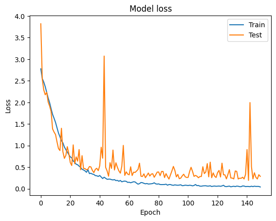

```python
accuracy = history_131.history['accuracy']
val_accuracy = history_131.history['val_accuracy']
loss = history_131.history['loss']
val_loss = history_131.history['val_loss']

epochs = range(1, len(accuracy) + 1)

plt.plot(epochs, accuracy, label='Training accuracy')
plt.plot(epochs, val_accuracy, label= 'Validation accuracy')
plt.title('Training and Validation accuracy')
plt.legend()
plt.figure()

def plot_loss(loss,val_loss):
  plt.figure()
  plt.plot(loss)
  plt.plot(val_loss)
  plt.title('Model loss')
  plt.ylabel('Loss')
  plt.xlabel('Epoch')
  plt.legend(['Train', 'Test'], loc='upper right')
  plt.show()

plot_loss(loss, val_loss)

plt.show()
```

We can see that this model is well fitted but inconsistent

```python
scores_131 = model131.evaluate(X_test, y_test)
print("\n%s: %.2f%%" % (model131.metrics_names[1], scores_131[1]*100))
```

```
accuracy: 95.97%
```

```python
model131.save_weights('model131_weights.h5')
model131.save('model131.h5')
```

#### With Augmentation

```python
model131_aug = Sequential()

# First Convolutional Block
model131_aug.add(Conv2D(32, (3, 3), activation='relu', input_shape=(131, 131, 1)))
model131_aug.add(BatchNormalization())
model131_aug.add(Conv2D(32, (3, 3), activation='relu'))
model131_aug.add(BatchNormalization())
model131_aug.add(MaxPooling2D((2, 2)))
model131_aug.add(Dropout(0.25))

# Second Convolutional Block
model131_aug.add(Conv2D(64, (3, 3), activation='relu'))
model131_aug.add(BatchNormalization())
model131_aug.add(Conv2D(64, (3, 3), activation='relu'))
model131_aug.add(BatchNormalization())
model131_aug.add(MaxPooling2D((2, 2)))
model131_aug.add(Dropout(0.3))

# Third Convolutional Block
model131_aug.add(Conv2D(128, (3, 3), activation='relu'))
model131_aug.add(BatchNormalization())
model131_aug.add(Conv2D(128, (3, 3), activation='relu'))
model131_aug.add(BatchNormalization())
model131_aug.add(MaxPooling2D((2, 2)))  # Adjusted max pooling
model131_aug.add(Dropout(0.4))

# Fully Connected Layers
model131_aug.add(Flatten())
model131_aug.add(Dense(128, activation='relu'))
model131_aug.add(Dropout(0.4))  # Increased dropout for better regularization

model131_aug.add(Dense(64, activation='relu'))
model131_aug.add(Dropout(0.3))  # Adjusted dropout

model131_aug.add(Dense(15, activation='softmax'))
```

```python
# Define the learning rate
learning_rate = 0.0001

# Create Adam optimizer with specified learning rate
optimizer = Adam(learning_rate=learning_rate)

model131_aug.compile(optimizer=optimizer, loss='categorical_crossentropy', metrics=['accuracy'])
```

```python
history = model131_aug.fit(X_train_aug, y_train, epochs=150 , verbose=1, validation_data=(X_val, y_val), class_weight=class_weights)
```

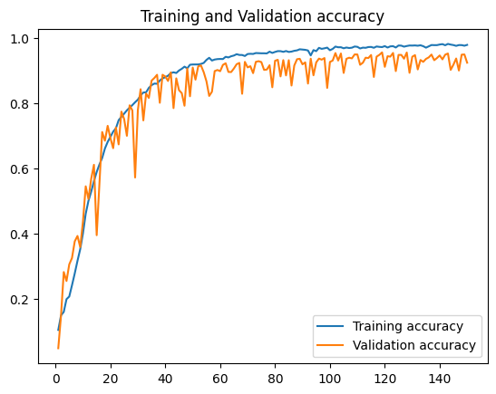

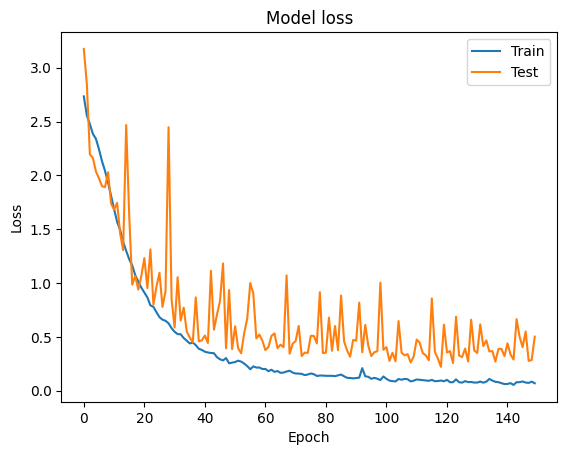

```python
accuracy = history.history['accuracy']
val_accuracy = history.history['val_accuracy']
loss = history.history['loss']
val_loss = history.history['val_loss']

epochs = range(1, len(accuracy) + 1)

plt.plot(epochs, accuracy, label='Training accuracy')
plt.plot(epochs, val_accuracy, label= 'Validation accuracy')
plt.title('Training and Validation accuracy')
plt.legend()
plt.figure()

def plot_loss(loss,val_loss):
  plt.figure()
  plt.plot(loss)
  plt.plot(val_loss)
  plt.title('Model loss')
  plt.ylabel('Loss')
  plt.xlabel('Epoch')
  plt.legend(['Train', 'Test'], loc='upper right')
  plt.show()

plot_loss(loss, val_loss)

plt.show()
```

We can see that the model is well fitted , but it is inconsistent

```python
scores = model131_aug.evaluate(X_test, y_test)
print("\n%s: %.2f%%" % (model131_aug.metrics_names[1], scores[1]*100))
```

```
accuracy: 92.77%
```

### Model Improvement

Using an educated decision making to configure our model's , we will improve our model that way.

### Final Model Evaluation(131 X 131)

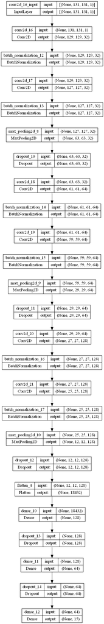

```python
from keras.utils.vis_utils import plot_model

# Plot the model
plot_model(model131, show_shapes=True, show_layer_names=True)
```

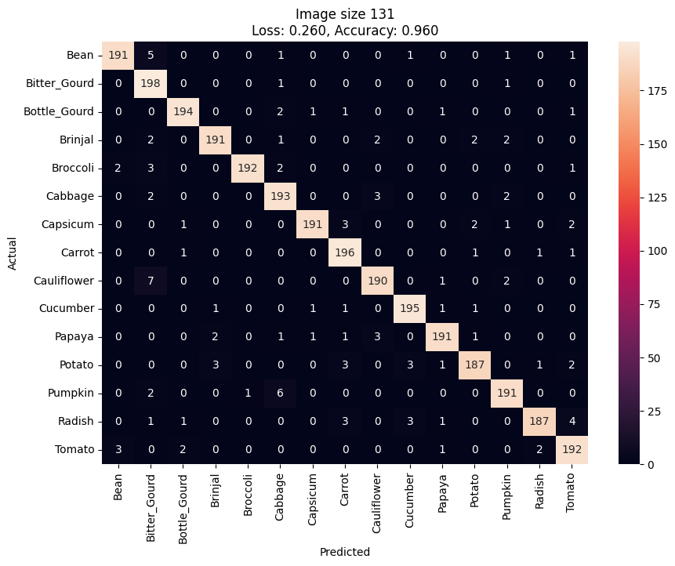

```python
y_pred = model131.predict(X_test)
from sklearn.metrics import confusion_matrix

confusion_matrix(np.argmax(y_test, axis=1), np.argmax(y_pred, axis=1))

#Graph the confusion matrix
import seaborn as sns
import pandas as pd

cm = confusion_matrix(np.argmax(y_test, axis=1), np.argmax(y_pred, axis=1))

pd.options.display.float_format = '{:.2f}'.format

df_cm = pd.DataFrame(cm, index = test_dataset.class_indices.keys(),
                    columns = test_dataset.class_indices.keys())

loss, accuracy = model131.evaluate(X_test, y_test)

plt.figure(figsize=(10,7))
sns.heatmap(df_cm, annot=True, fmt='d')
plt.title(f'Image size 131\nLoss: {loss:.3f}, Accuracy: {accuracy:.3f}')
plt.xlabel('Predicted')
plt.ylabel('Actual')
plt.show()
```

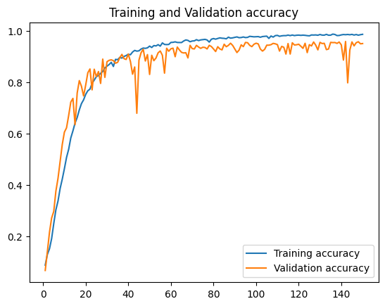

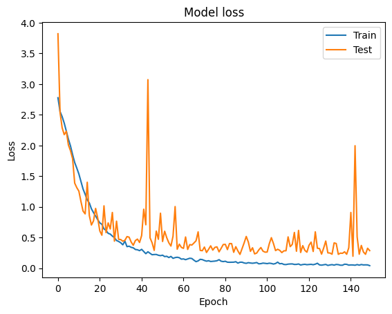

```python
accuracy = history_131.history['accuracy']
val_accuracy = history_131.history['val_accuracy']
loss = history_131.history['loss']
val_loss = history_131.history['val_loss']

epochs = range(1, len(accuracy) + 1)

plt.plot(epochs, accuracy, label='Training accuracy')
plt.plot(epochs, val_accuracy, label= 'Validation accuracy')
plt.title('Training and Validation accuracy')
plt.legend()
plt.figure()

def plot_loss(loss,val_loss):
  plt.figure()
  plt.plot(loss)
  plt.plot(val_loss)
  plt.title('Model loss')
  plt.ylabel('Loss')
  plt.xlabel('Epoch')
  plt.legend(['Train', 'Test'], loc='upper right')
  plt.show()

plot_loss(loss, val_loss)

plt.show()
```

```python
print("\n%s: %.2f%%" % (model131.metrics_names[1], scores_131[1]*100))
```

```
accuracy: 95.97%
```

```python
model131.save_weights('model131_weights.h5')
model131.save('model131.h5')
```

```python
model131.summary()
```

```
Model: "sequential_4"
_________________________________________________________________
 Layer (type)                Output Shape              Param #
=================================================================
 conv2d_16 (Conv2D)          (None, 129, 129, 32)      320

 batch_normalization_12 (Bat  (None, 129, 129, 32)     128
 chNormalization)

 conv2d_17 (Conv2D)          (None, 127, 127, 32)      9248

 batch_normalization_13 (Bat  (None, 127, 127, 32)     128
 chNormalization)

 max_pooling2d_8 (MaxPooling  (None, 63, 63, 32)       0
 2D)

 dropout_10 (Dropout)        (None, 63, 63, 32)        0

 conv2d_18 (Conv2D)          (None, 61, 61, 64)        18496

 batch_normalization_14 (Bat  (None, 61, 61, 64)       256
 chNormalization)

 conv2d_19 (Conv2D)          (None, 59, 59, 64)        36928

 batch_normalization_15 (Bat  (None, 59, 59, 64)       256
 chNormalization)

 max_pooling2d_9 (MaxPooling  (None, 29, 29, 64)       0
 2D)

 dropout_11 (Dropout)        (None, 29, 29, 64)        0

 conv2d_20 (Conv2D)          (None, 27, 27, 128)       73856

 batch_normalization_16 (Bat  (None, 27, 27, 128)      512
 chNormalization)

 conv2d_21 (Conv2D)          (None, 25, 25, 128)       147584
```

[output cut: 11 more lines]

```
 dense_10 (Dense)            (None, 128)               2359424

 dropout_13 (Dropout)        (None, 128)               0

 dense_11 (Dense)            (None, 64)                8256

 dropout_14 (Dropout)        (None, 64)                0

 dense_12 (Dense)            (None, 15)                975

=================================================================
Total params: 2,656,879
Trainable params: 2,655,983
Non-trainable params: 896
_________________________________________________________________
```

### Conclusion

Using an educated guess to do my configuration of my models architecture.Our best Model is my 131 Model without the Augmented Data.Getting an accuracy of..

```python
scores_131[1]*100
```

```
95.96666693687439
```